# 2000年台灣百貨行銷策略之研究與規劃

組員：`B044030015 許效軒` `B046060036 王文弘` `B054012011 黃冠綾` `B046060027 姚詠馨` `B046060035 張文瑜` `M074020024 楊長舜`

本組從kaggle上抓取2000年11月至2001年2月大峰百貨的銷售與交易資料，希望能了解該百貨的現況，分析顧客價值，並予以行銷策略，以最有效率的方式，提升未來期望報酬。

**目錄**

- 壹、現況總覽
- 貳、重要品類分析
- 參、整體與品類分群
- 肆、行銷策略發想
- 伍、模型與成本效益預測
- 陸、總結

### 讀入套件

```r
rm(list=ls(all=T))
Sys.setlocale("LC_TIME","C")
```

```
## [1] "C"
```

```r
pacman::p_load(magrittr, readr, caTools, ggplot2, dplyr,MASS, dendextend, vegan, randomcoloR, googleVis,knitr,kableExtra,rmdformats,tidyr)
options(knitr.table.format = "html")
```

# 壹、現況總覽

## 1.1 讀進資料

```r
Z = read_csv("ta_feng_all_months_merged.csv") %>% data.frame %>%
  setNames(c("date","cust","age","area","cat","prod","qty","cost","price"))
nrow(Z)
```

```
## [1] 817741
```

#### 資料格式轉換

```r
Z$date = as.Date(Z$date, format="%m/%d/%Y")
Z$age[is.na(Z$age)] = "na"
Z$age = factor(Z$age, levels=c(
  "<25","25-29","30-34","35-39","40-44","45-49","50-54","55-59","60-64",">65","na"), labels=c(
  "a20","a25","a30","a35","a40","a45","a50","a55","a60","a65","na"
  )) %>% as.character
Z$area = paste0("z",Z$area)
summary(Z)
```

```
##       date                cust               age
##  Min.   :2000-11-01   Length:817741      Length:817741
##  1st Qu.:2000-11-28   Class :character   Class :character
##  Median :2001-01-01   Mode  :character   Mode  :character
##  Mean   :2000-12-30
##  3rd Qu.:2001-01-30
##  Max.   :2001-02-28
##      area                cat             prod                qty
##  Length:817741      Min.   :100101   Length:817741      Min.   :   1.000
##  Class :character   1st Qu.:110106   Class :character   1st Qu.:   1.000
##  Mode  :character   Median :130106   Mode  :character   Median :   1.000
##                     Mean   :284951                      Mean   :   1.382
##                     3rd Qu.:520314                      3rd Qu.:   1.000
##                     Max.   :780510                      Max.   :1200.000
##       cost              price
##  Min.   :     0.0   Min.   :     1.0
##  1st Qu.:    35.0   1st Qu.:    42.0
##  Median :    62.0   Median :    76.0
##  Mean   :   112.1   Mean   :   131.9
##  3rd Qu.:   112.0   3rd Qu.:   132.0
##  Max.   :432000.0   Max.   :444000.0
```

#### 處理離群值

```r
# Quantile of Variables
sapply(Z[,7:9], quantile, prob=c(.99, .999, .9995))
```

```
##        qty   cost   price
## 99%      6  858.0 1014.00
## 99.9%   14 2722.0 3135.82
## 99.95%  24 3799.3 3999.00
```

```r
# Remove Outliers
Z = subset(Z, qty<=24 & cost<=3800 & price<=4000)
nrow(Z)
```

```
## [1] 817182
```

#### 彙總

```r
Z$tid = group_indices(Z, date, cust)
```

## 1.2各月分訂單數

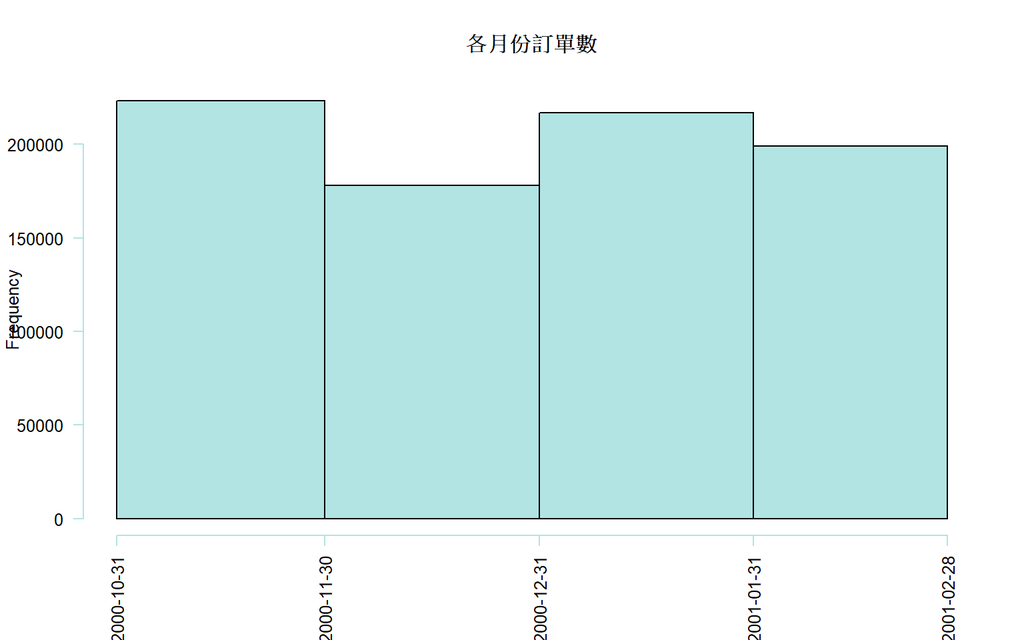

```r
par(cex=0.8)
hist(Z$date,"months",las=2,freq=T,xlab="",main ="各月份訂單數",col ="#B1E4E3")
```

## 1.3顧客資訊摘要

共有32256位顧客。

```r
n_distinct(Z$cust)
```

```
## [1] 32256
```

### 1.3.1各年齡族群購買總數分布

35-39歲顧客總購買數量最高。

```r
tapply(Z$qty, Z$age, sum) %>% sort()
```

```
##    a60     na    a55    a65    a20    a50    a25    a45    a30    a40
##  28701  30064  35130  39373  39699  75810  88768 138364 186582 204228
##    a35
## 243199
```

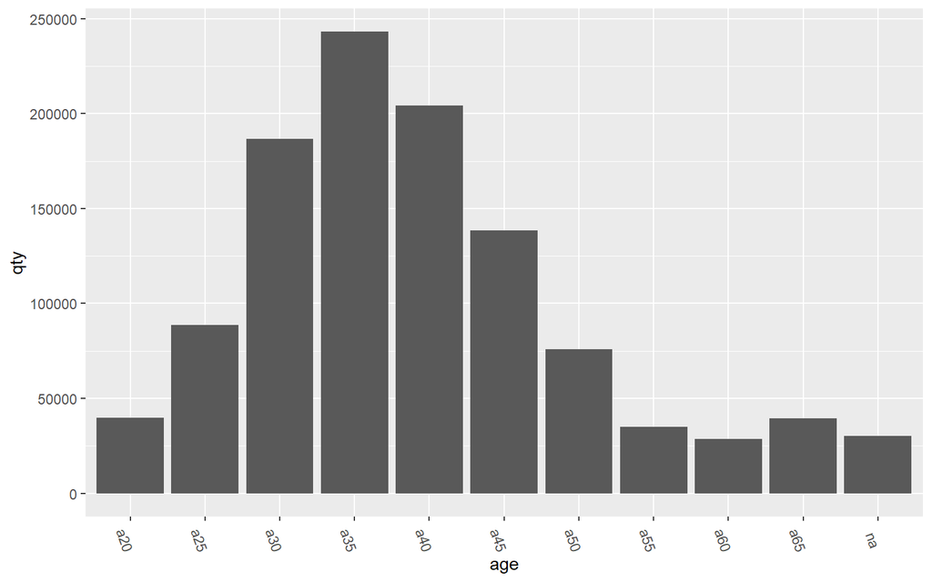

```r
ggplot(Z, aes(x =age, y = qty) )+
  geom_bar(stat = "identity")+
  theme(axis.text.x = element_text(angle = -70))
```

### 1.3.2各年齡族群花費總金額分布

35-39歲顧客總購買數量最高且總花費金額也最高。

```r
tapply(Z$price, Z$age, sum) %>% sort()
```

```
##      a60       na      a65      a55      a20      a50      a25      a45
##  2590053  2799954  3140273  3189497  3545743  6542456  8682042 12012600
##      a40      a30      a35
## 18291925 18824963 22965740
```

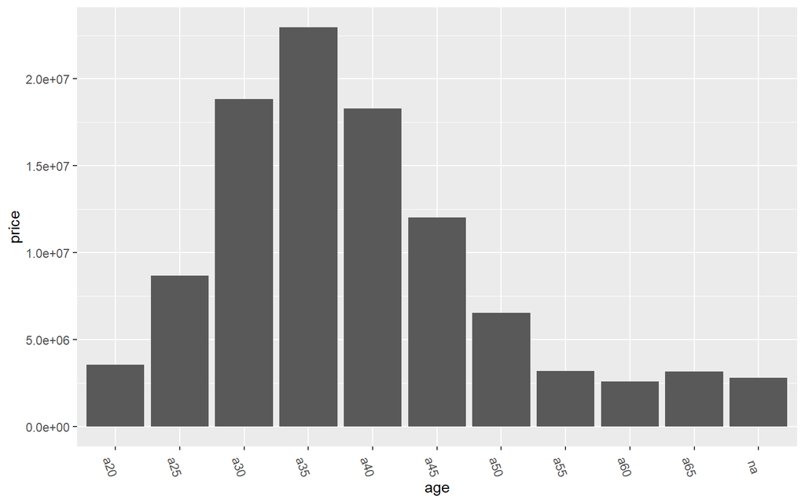

```r
ggplot(Z, aes(x = age, y =price) )+
  geom_bar(stat = "identity")+
  theme(axis.text.x = element_text(angle = -70))
```

### 1.3.3各年齡層客戶偏好消費時間

客戶們都傾向在假日來商場購物，尤其是30到40歲這群人最為明顯。

```r
# 換成比例可以真正看出各年齡人數不同的問題，當數量不一致不能比較時換成比率是較好的方法。
library(d3heatmap)
table(Z$age,format(Z$date,"%u")) %>%
  {./rowSums(.)} %>%
  as.data.frame.matrix %>%
  d3heatmap(F,F,col="Greens")
```

[interactive chart not shown]

### 1.3.3各區域客戶偏好消費時間

住在松山區、大安區、信義區、內湖區明顯傾向在週日購物，推估是因為地緣位置相對其他區域（南港區、汐止區）比較遠，所以假日來購物會比較有充裕時間。

```r
table(Z$area, format(Z$date,"%u"))  %>%
  {./rowSums(.)} %>%
  as.data.frame.matrix %>%
  d3heatmap(F,F,col="Greens")
```

[interactive chart not shown]

## 1.4顧客消費資料變數分布

```r
A = Z %>%
  mutate(days = as.integer(as.Date("2001-03-01") - as.Date(date))) %>%
  group_by(cust) %>% summarise(
    recent = min(days),     # 最近購買距今天數
    freq = n(),             # 購買次數
    money = mean(price),   # 平均購買金額
    senior = max(days),     # 第一次購買距今天數
    since = min(date) # 第一次購買日期
  ) %>% data.frame
```

### 1.4.1 變數摘要

```r
summary(A)
```

```
##      cust               recent            freq             money
##  Length:32256       Min.   :  1.00   Min.   :   1.00   Min.   :   8.00
##  Class :character   1st Qu.:  9.00   1st Qu.:   6.00   1st Qu.:  81.29
##  Mode  :character   Median : 26.00   Median :  14.00   Median : 110.71
##                     Mean   : 37.44   Mean   :  25.33   Mean   : 150.45
##                     3rd Qu.: 59.25   3rd Qu.:  32.00   3rd Qu.: 157.61
##                     Max.   :120.00   Max.   :1246.00   Max.   :3980.00
##      senior           since
##  Min.   :  1.00   Min.   :2000-11-01
##  1st Qu.: 56.00   1st Qu.:2000-11-11
##  Median : 92.00   Median :2000-11-29
##  Mean   : 80.78   Mean   :2000-12-10
##  3rd Qu.:110.00   3rd Qu.:2001-01-04
##  Max.   :120.00   Max.   :2001-02-28
```

### 1.4.2 變數分布檢視

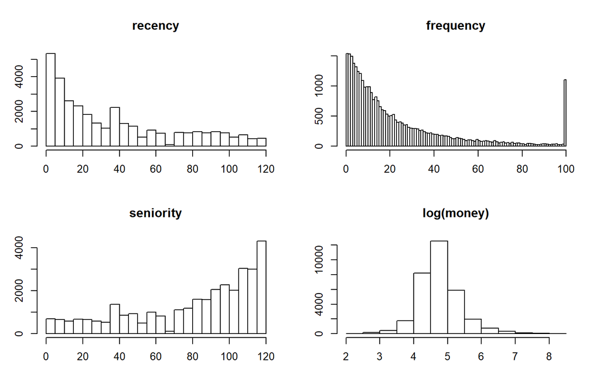

```r
p0 = par(cex=0.8, mfrow=c(2,2), mar=c(3,3,4,2))
hist(A$recent,25,main="recency",ylab="",xlab="")
hist(pmin(A$freq, 100),0:100,main="frequency",ylab="",xlab="")
hist(A$senior,20,main="seniority",ylab="",xlab="")
hist(log(A$money),main="log(money)",ylab="",xlab="")
```

## 1.5 品類動態趨勢圖

```r
# 對品類做彙總
Z= Z %>% mutate(avgprice = price/qty)

category = filter(Z, !is.na(cat)) %>%
  group_by(cat) %>% summarise(
    itemsSold = sum(qty),
    totalRev = sum(price),
    avgPrice = sum(price)/sum(qty),
    gross = sum(price - cost),
    cost = mean(cost),
    noProduct = n_distinct(prod),
    nobuyer = n_distinct(cust)
  ) %>% arrange(desc(gross))
# 篩選總利潤最大的20個品類
top20 = category$cat[1:20]
category[1:20,]
```

```
## # A tibble: 20 x 8
##       cat itemsSold totalRev avgPrice  gross   cost noProduct nobuyer
##     <dbl>     <dbl>    <dbl>    <dbl>  <dbl>  <dbl>     <int>   <int>
##  1 320402      1463  1481172   1012.  349458  925.        129     696
##  2 560201     14752  4329366    293.  288855  531.         68    3874
##  3 560402      7885  3634174    461.  226535  694.         75    2625
##  4 100205     24553  1222044     49.8 200685   50.1       275    9693
##  5 530101     14335  1161968     81.1 184621   92.5        88    5148
##  6 530110      6517  1192350    183.  161002  173.        135    4345
##  7 530105      7417   862488    116.  135059  114.         83    4683
##  8 110401     15614   801041     51.3 131450   51.1        73    6587
##  9 100102     11175   820440     73.4 131083   81.1       136    4907
## 10 130206     14352   911146     63.5 128736   65.2        76    5914
## 11 470105       669   783751   1172.  126135 1111.         31     312
## 12 520457      5028   808004    161.  126080  281.         38    1844
## 13 320501      2137   514550    241.  124946  257.        195     875
## 14 530114      4891   821197    168.  120765  163.        132    3215
## 15 470103       569   659723   1159.  110506 1231.         34     306
## 16 500804     11923   650290     54.5  98508  127.         86    1380
## 17 130204     12063   950573     78.8  96784   78.7        46    5469
## 18 110333       929   567365    611.   94753  702.         81     527
## 19 100414      4711   532424    113.   93083  118.         65    2386
## 20 100401      3802  1197920    315.   92294  325.         63    2574
```

#### 與時間軸彙整

```r
# 對品類(`category`)和月份(`months`)做彙總
Z_C = Z %>%  mutate(
  months = as.Date(cut(date, "months"))) %>%  # cut timestamp into months
  filter(cat%in% top20) %>%  # top20 品類
  group_by(cat, months) %>% #根據每個品項每月會有一個值
  summarise(
    itemsSold = sum(qty),
    totalRev = sum(price),
    avgPrice = sum(price)/sum(qty),
    gross = sum(price - cost),
    cost = mean(cost),
    noProduct = n_distinct(prod),
    nobuyer = n_distinct(cust)
  ) %>%
  arrange(cat, months)
Z_C2 = Z_C %>% as.data.frame

# 動態圖,總利潤最大的20個品類
plot( gvisMotionChart(
  Z_C2, "cat", "months",
  options=list(width=800, height=600) ))
```

```
## starting httpd help server ... done
```

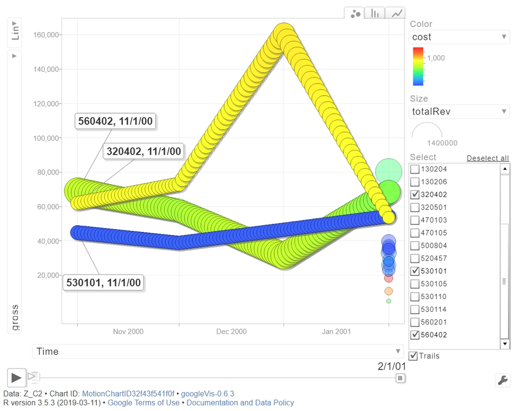

總利潤最大的20個品類動態泡泡圖

# 貳、重要品類分析

## 2.1 編號320402－家電類

### 2.1.1 概覽

```r
cat1 = subset(Z, cat=="320402") #篩選出320402品類資料

cat2 = cat1 %>% group_by(tid) %>% summarise(
  date = date[1],             # 交易日期
  cust = cust[1],             # 顧客 ID
  age = age[1],               # 顧客 年齡級別
  area = area[1],             # 顧客 居住區別
  items = n(),                # 交易項目(總)數
  pieces = sum(qty),          # 產品(總)件數
  total = sum(price),         # 交易(總)金額
  gross = sum(price - cost)   # 毛利
  ) %>% data.frame
nrow(cat2) # 824筆訂單
```

```
## [1] 824
```

```r
summary(cat2)
```

```
##       tid              date                cust
##  Min.   :   144   Min.   :2000-11-01   Length:824
##  1st Qu.: 37910   1st Qu.:2000-12-06   Class :character
##  Median : 69231   Median :2001-01-14   Mode  :character
##  Mean   : 63002   Mean   :2001-01-04
##  3rd Qu.: 83432   3rd Qu.:2001-01-25
##  Max.   :119301   Max.   :2001-02-28
##      age                area               items           pieces
##  Length:824         Length:824         Min.   :1.000   Min.   : 1.000
##  Class :character   Class :character   1st Qu.:1.000   1st Qu.: 1.000
##  Mode  :character   Mode  :character   Median :1.000   Median : 1.000
##                                        Mean   :1.484   Mean   : 1.775
##                                        3rd Qu.:2.000   3rd Qu.: 2.000
##                                        Max.   :8.000   Max.   :10.000
##      total           gross
##  Min.   :   94   Min.   :-302.0
##  1st Qu.: 1129   1st Qu.: 253.0
##  Median : 1242   Median : 311.0
##  Mean   : 1798   Mean   : 424.1
##  3rd Qu.: 2360   3rd Qu.: 592.0
##  Max.   :12708   Max.   :3434.0
```

#### 處理離群值

```r
sapply(cat2[,6:9], quantile, prob=c(.999, .9995, .9999))
```

```
##         items pieces     total    gross
## 99.9%  6.3540 8.3540  8567.487 2205.261
## 99.95% 7.1770 9.1770 10637.744 2819.631
## 99.99% 7.8354 9.8354 12293.949 3311.126
```

```r
cat2 = subset(cat2, items<=62 & pieces<95 & total<16000) # 119328
```

### 2.1.2 每周交易次數

在2001年1月第3周購買次數暴增，正好遇到農曆過年前一周，多為家庭採購年貨時間，因此可能單量暴增，而第四周為過年周，家庭多四處拜年而不採購年貨。

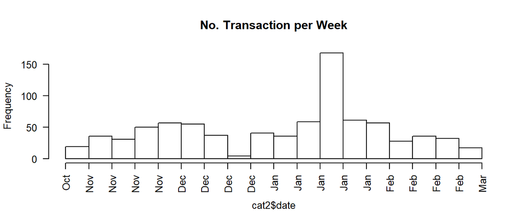

```r
par(cex=0.8)
hist(cat2$date, "weeks", freq=T, las=2, main="No. Transaction per Week")
```

### 2.1.3 偏好購買時間

此品類消費者偏好在假日購物，尤其是禮拜天；60至65歲偏向週六購物。

```r
table(cat2$age, format(cat2$date,"%u")) %>%
  {./rowSums(.)}%>%
  as.data.frame.matrix %>%
  d3heatmap(F,F,col=colorRamp(c('seagreen','lightyellow','red')))
```

[interactive chart not shown]

### 2.1.4 各年齡層淨利

從利潤的角度來看，25-45的青壯年仍為主要營收貢獻者，其中35-45歲所帶來的利潤最高。

```r
tapply(cat2$gross, cat2$age, sum) %>% sort()
```

```
##   a65   a60   a55   a20   a50    na   a25   a30   a45   a35   a40
##  2681  6120  9155 17133 18486 22023 39799 49624 53420 60597 70420
```

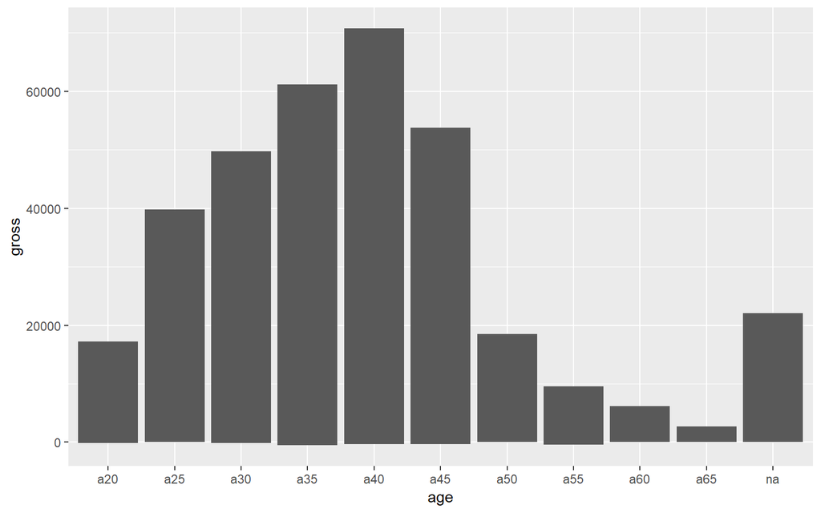

```r
ggplot(cat2, aes(x = age, y = gross) )+
  geom_bar(stat = "identity")
```

### 2.1.5 各區域淨利

根據地區來探索，在z115南港與z221汐止的消費者作喜歡購買此類商品，但其實此兩區本來就是整間賣場客戶來源。

```r
tapply(cat2$gross,cat2$area, sum) %>% sort()
```

```
##     z105     z106     z114     z110  zOthers zUnknown     z221     z115
##     2663     4192    14914    16782    22992    35472   104302   148141
```

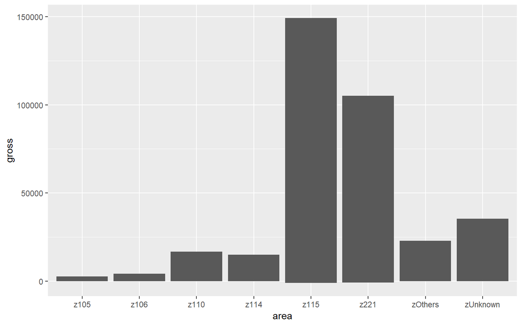

```r
ggplot(cat2, aes(x = area, y = gross) )+
  geom_bar(stat = "identity")
```

### 2.1.6 顧客消費資料變數分布

```r
d1 = max(cat2$date) + 1
cat2A = cat2 %>% mutate(
  days = as.integer(difftime(d1, date, units="days"))
  ) %>%
  group_by(cust) %>% summarise(
    r = min(days),      # recency
    s = max(days),      # seniority
    f = n(),            # frquency
    m = mean(total),    # monetary #平均客單價
    rev = sum(total),   # total revenue contribution
    raw = sum(gross),   # total gross profit contribution
    age = age[1],       # age group
    area = area[1],     # area code
  ) %>% data.frame
nrow(cat2A) # 696位顧客
```

```
## [1] 696
```

```r
summary(cat2A)
```

```
##      cust                 r                s               f
##  Length:696         Min.   :  1.00   Min.   :  1.0   Min.   :1.000
##  Class :character   1st Qu.: 32.00   1st Qu.: 37.0   1st Qu.:1.000
##  Mode  :character   Median : 43.00   Median : 46.5   Median :1.000
##                     Mean   : 53.28   Mean   : 57.5   Mean   :1.184
##                     3rd Qu.: 81.00   3rd Qu.: 86.0   3rd Qu.:1.000
##                     Max.   :119.00   Max.   :120.0   Max.   :7.000
##        m             rev             raw             age
##  Min.   :  94   Min.   :   94   Min.   : -52.0   Length:696
##  1st Qu.:1152   1st Qu.: 1152   1st Qu.: 275.0   Class :character
##  Median :1289   Median : 1632   Median : 359.0   Mode  :character
##  Mean   :1779   Mean   : 2128   Mean   : 502.1
##  3rd Qu.:2364   3rd Qu.: 2484   3rd Qu.: 622.0
##  Max.   :7182   Max.   :15209   Max.   :4001.0
##      area
##  Length:696
##  Class :character
##  Mode  :character
##
##
##
```

### 2.1.7 變數分布檢視

- recently：此品類消費顧客有約半數在43天內消費過，在距今30至40天時，特別多人在這期間消費。
- seniority：在距今30至40天時湧入(約2001年1月第三周前後)，有大量新顧客湧入；而距今80天處，約為12月中旬新顧客也略有增加，可能與聖誕節前促銷有關。
- frequency：消費者購買次數多為1至2次，代表顧客忠誠度不高，在五個月內回購次數低。
- money：平均客單價之平均為1779元，經取log後發現其平均約呈常態分配。

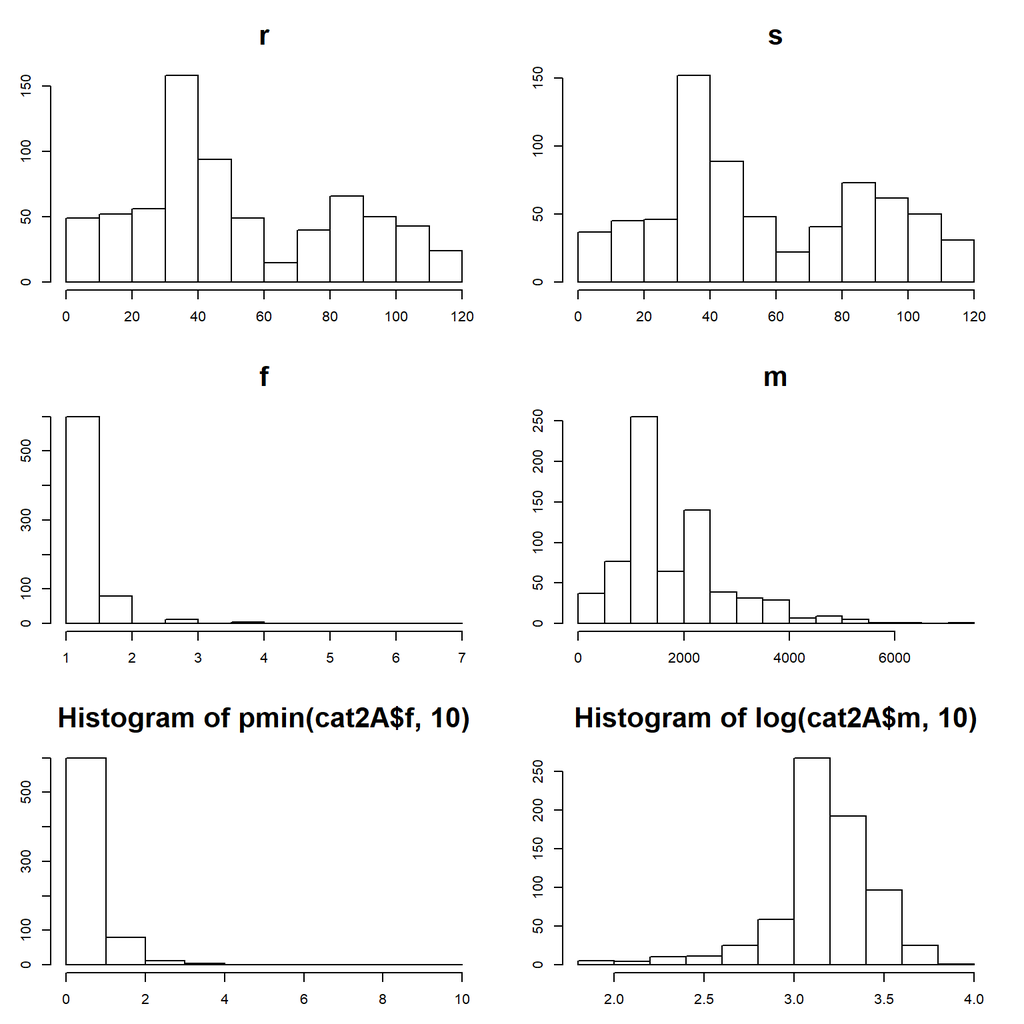

```r
par(mfrow=c(3,2), mar=c(3,3,4,2))
for(x in c('r','s','f','m'))
hist(cat2A[,x],freq=T,main=x,xlab="",ylab="",cex.main=2)
hist(pmin(cat2A$f,10),0:10,freq=T,xlab="",ylab="",cex.main=2)
hist(log(cat2A$m,10),freq=T,xlab="",ylab="",cex.main=2)
```

### 2.1.8 回購機率摘要

```r
feb01 = as.Date("2001-02-01")
cat1 = subset(cat1, date < feb01)
feb = filter(cat2, date>= feb01) %>% group_by(cust) %>%
  summarise(amount = sum(total))


cat2A= merge(cat2A, feb, by="cust", all.x=T)
cat2A$buy = !is.na(cat2A$amount)

summary(cat2A)
```

```
##      cust                 r                s               f
##  Length:696         Min.   :  1.00   Min.   :  1.0   Min.   :1.000
##  Class :character   1st Qu.: 32.00   1st Qu.: 37.0   1st Qu.:1.000
##  Mode  :character   Median : 43.00   Median : 46.5   Median :1.000
##                     Mean   : 53.28   Mean   : 57.5   Mean   :1.184
##                     3rd Qu.: 81.00   3rd Qu.: 86.0   3rd Qu.:1.000
##                     Max.   :119.00   Max.   :120.0   Max.   :7.000
##
##        m             rev             raw             age
##  Min.   :  94   Min.   :   94   Min.   : -52.0   Length:696
##  1st Qu.:1152   1st Qu.: 1152   1st Qu.: 275.0   Class :character
##  Median :1289   Median : 1632   Median : 359.0   Mode  :character
##  Mean   :1779   Mean   : 2128   Mean   : 502.1
##  3rd Qu.:2364   3rd Qu.: 2484   3rd Qu.: 622.0
##  Max.   :7182   Max.   :15209   Max.   :4001.0
##
##      area               amount        buy
##  Length:696         Min.   : 108   Mode :logical
##  Class :character   1st Qu.:1152   FALSE:566
##  Mode  :character   Median :1242   TRUE :130
##                     Mean   :1786
##                     3rd Qu.:2340
##                     Max.   :7182
##                     NA's   :566
```

### 2.1.9 年齡與回購率

65歲以上的消費者購買機率最高，其次是55-60歲之消費者，第三是小於25歲之消費者與35-40的消費者。  
50-55的消費者購物機率最低，因此可能選擇放棄類消費者。

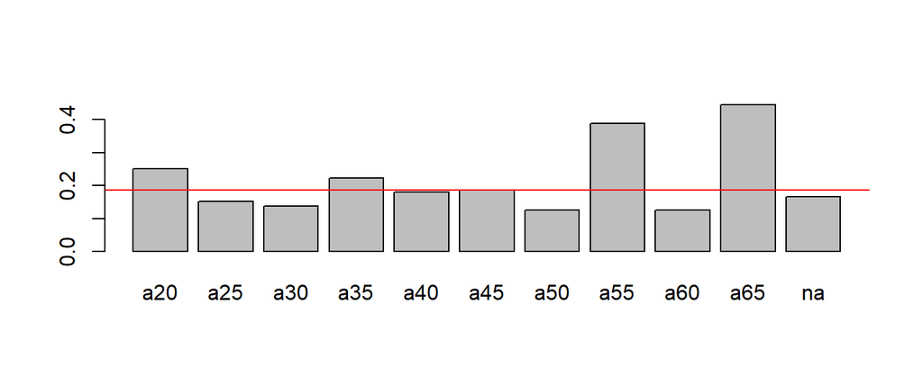

```r
tapply(cat2A$buy, cat2A$age, mean) %>% barplot
abline(h = mean(cat2A$buy), col='red')
```

### 2.1.10 地區與回購率

從地區購買機率來看，106大安區有最高的購買機率，110信義區為第二高的購買機率，再來是原本最多人來購物的115南港。

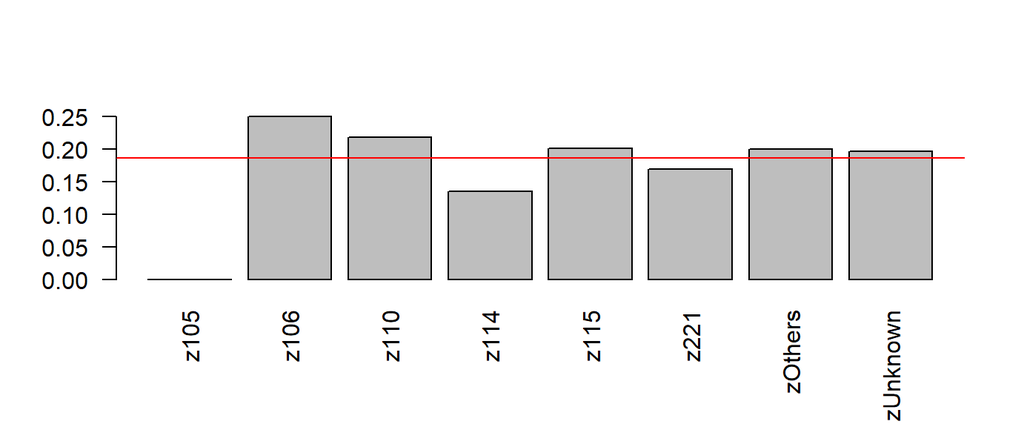

```r
tapply(cat2A$buy, cat2A$area, mean) %>% barplot(las=2)
abline(h = mean(cat2A$buy), col='red')
```

> 統合此類產品特徵：  
> 1. 農曆過年前一周購買次數暴增。  
> 2. 偏好在假日購物，尤其是禮拜天，60至65歲偏向週六購物。  
> 3. 從利潤來看，25-45的青壯年仍為主要營收貢獻者，其中35-45歲所帶來的利潤最高。  
> 4. 南港與汐止的消費者最喜歡購買此類商品，但此兩區本來就是整間賣場客戶來源。  
> 5. 此品類消費顧客有約半數在43天內消費過，在距今30至40天時，特別多人在這期間消費。  
> 6. 在年貨促銷期間，有大量新顧客湧入。  
> 7. 消費者購買次數多為1至2次，代表顧客忠誠度不高。  
> 8. 平均客單價之平均為1779元。  
> 9. 65歲以上的消費者購買機率最高。  
> 10. 106大安區和110信義區的購買機率都蠻高的。  
> 11. 根據毛利趨勢圖，此品類商品毛利在1月大幅成長，但在2月大幅衰退，且此商品屬銷售成本偏高之產品。  
> 12. 購買數量跟其他品類相比很低，雖成本高，但毛利也高，代表其單價應較高，平均客單價約在1779元上下。

> > 此類商品假設：由於此類商品單價較高、購買客戶偏少，五個月內回購次數低且會受年節影響，故假設此類商品為家電用品。

## 2.2 編號560402－冬季保暖衣物類

### 2.2.1 概覽

```r
cat3 = subset(Z, cat=="560402") #篩選出560402品類資料

cat4 = cat3 %>% group_by(tid) %>% summarise(
  date = date[1],             # 交易日期
  cust = cust[1],             # 顧客 ID
  age = age[1],               # 顧客 年齡級別
  area = area[1],             # 顧客 居住區別
  items = n(),                # 交易項目(總)數
  pieces = sum(qty),          # 產品(總)件數
  total = sum(price),         # 交易(總)金額
  gross = sum(price - cost)   # 毛利
  ) %>% data.frame
nrow(cat4)   # 4287筆訂單
```

```
## [1] 4287
```

```r
summary(cat4)
```

```
##       tid              date                cust
##  Min.   :    18   Min.   :2000-11-01   Length:4287
##  1st Qu.: 30148   1st Qu.:2000-11-29   Class :character
##  Median : 63700   Median :2001-01-08   Mode  :character
##  Mean   : 60294   Mean   :2001-01-01
##  3rd Qu.: 88194   3rd Qu.:2001-01-31
##  Max.   :119411   Max.   :2001-02-28
##      age                area               items           pieces
##  Length:4287        Length:4287        Min.   :1.000   Min.   : 1.000
##  Class :character   Class :character   1st Qu.:1.000   1st Qu.: 1.000
##  Mode  :character   Mode  :character   Median :1.000   Median : 1.000
##                                        Mean   :1.145   Mean   : 1.839
##                                        3rd Qu.:1.000   3rd Qu.: 2.000
##                                        Max.   :6.000   Max.   :12.000
##      total            gross
##  Min.   : 179.0   Min.   :-338.00
##  1st Qu.: 425.0   1st Qu.:  28.00
##  Median : 619.0   Median :  48.00
##  Mean   : 847.7   Mean   :  52.84
##  3rd Qu.:1018.0   3rd Qu.:  80.00
##  Max.   :5426.0   Max.   : 500.00
```

#### 處理離群值

```r
sapply(cat4[,6:9], quantile, prob=c(.999, .9995, .9999))
```

```
##         items pieces    total   gross
## 99.9%  4.0000 10.000 5397.114 399.854
## 99.95% 4.0000 10.857 5426.000 428.854
## 99.99% 5.5714 12.000 5426.000 491.428
```

```r
cat4 = subset(cat4, items<=62 & pieces<95 & total<16000)
```

### 2.2.2 每周交易次數

2000年11月中後至12月初與2001年1月中購買次數較高。

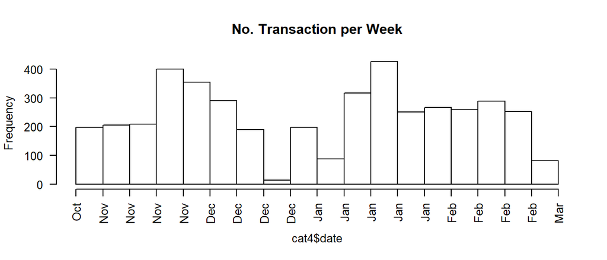

```r
par(cex=0.8)
hist(cat4$date, "weeks", freq=T, las=2, main="No. Transaction per Week")
```

### 2.2.3 偏好購買時間

此品類消費者偏好在假日購物，星期日更甚於星期六。

```r
table(cat4$age, format(cat4$date,"%u")) %>%
  {./rowSums(.)}%>%
  as.data.frame.matrix %>%
  d3heatmap(F,F,col=colorRamp(c('seagreen','lightyellow','red')))
```

[interactive chart not shown]

### 2.2.4 各年齡層淨利

從利潤的角度來看，30-40歲為主要客戶群，比起其他顧客突出很多。

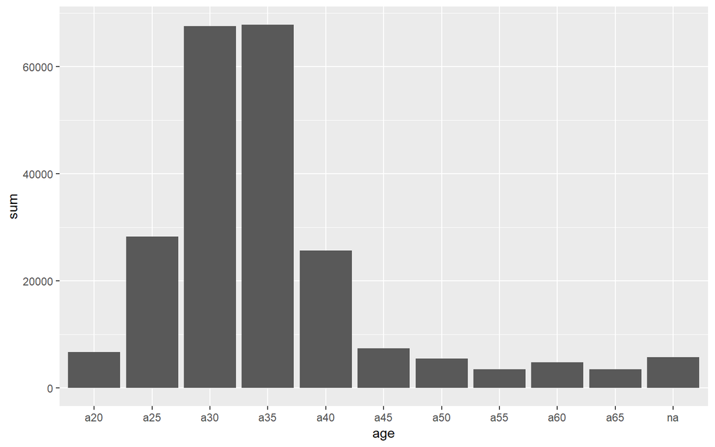

```r
cat4 %>%
  group_by(age) %>%
  summarise(sum = sum(gross)) %>%
ggplot(aes(x = age, y = sum) )+
  geom_bar(stat = "identity")
```

### 2.2.5 各區域淨利

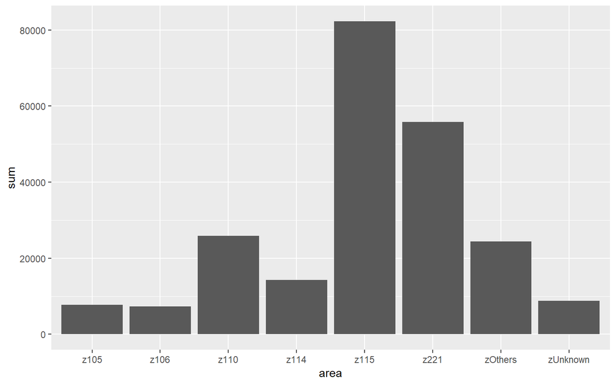

```r
cat4 %>%
  group_by(area) %>%
  summarise(sum = sum(gross)) %>%
ggplot(aes(x = area, y = sum) )+
  geom_bar(stat = "identity")
```

### 2.2.6 顧客消費資料變數分布

```r
d1 = max(cat4$date) + 1
cat4A = cat4 %>% mutate(
  days = as.integer(difftime(d1, date, units="days"))
  ) %>%
  group_by(cust) %>% summarise(
    r = min(days),      # recency
    s = max(days),      # seniority
    f = n(),            # frquency
    m = mean(total),    # monetary #平均客單價
    rev = sum(total),   # total revenue contribution
    raw = sum(gross),   # total gross profit contribution
    age = age[1],       # age group
    area = area[1],     # area code
  ) %>% data.frame
nrow(cat4A)   # 2625位顧客
```

```
## [1] 2625
```

```r
summary(cat4A)
```

```
##      cust                 r                s                f
##  Length:2625        Min.   :  1.00   Min.   :  1.00   Min.   : 1.000
##  Class :character   1st Qu.: 18.00   1st Qu.: 37.00   1st Qu.: 1.000
##  Mode  :character   Median : 40.00   Median : 80.00   Median : 1.000
##                     Mean   : 48.31   Mean   : 67.93   Mean   : 1.633
##                     3rd Qu.: 82.00   3rd Qu.: 98.00   3rd Qu.: 2.000
##                     Max.   :120.00   Max.   :120.00   Max.   :18.000
##        m               rev             raw             age
##  Min.   : 179.0   Min.   :  179   Min.   :-242.0   Length:2625
##  1st Qu.: 469.0   1st Qu.:  515   1st Qu.:  28.0   Class :character
##  Median : 653.0   Median :  938   Median :  58.0   Mode  :character
##  Mean   : 877.9   Mean   : 1384   Mean   :  86.3
##  3rd Qu.:1053.0   3rd Qu.: 1876   3rd Qu.: 122.0
##  Max.   :5426.0   Max.   :10881   Max.   : 980.0
##      area
##  Length:2625
##  Class :character
##  Mode  :character
##
##
##
```

### 2.2.7 變數分布檢視

- recently：此品類消費顧客約半數在40天內有消費過。
- seniority：新顧客大多都在距今80天前加入，但近期也有持續加入。
- frequency：大部分消費者購買次數多為1次，代表多數顧客忠誠度不高，除了少數幾人在五個月內回購次數低。
- money：平均客單價之平均為877元。

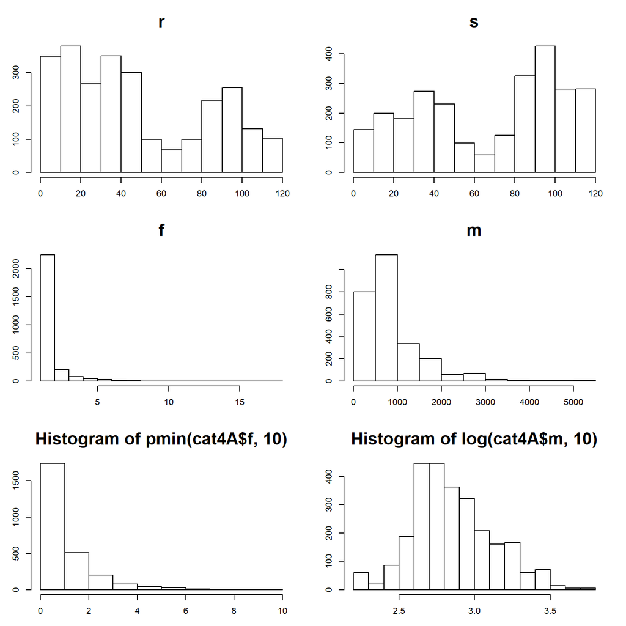

```r
par(mfrow=c(3,2), mar=c(3,3,4,2))
for(x in c('r','s','f','m'))
hist(cat4A[,x],freq=T,main=x,xlab="",ylab="",cex.main=2)
hist(pmin(cat4A$f,10),0:10,freq=T,xlab="",ylab="",cex.main=2)
hist(log(cat4A$m,10),freq=T,xlab="",ylab="",cex.main=2)
```

### 2.2.8 回購機率摘要

```r
feb01 = as.Date("2001-02-01")
cat3 = subset(cat3, date < feb01)
feb = filter(cat4, date>= feb01) %>% group_by(cust) %>%
  summarise(amount = sum(total))

cat4A= merge(cat4A, feb, by="cust", all.x=T)
cat4A$buy = !is.na(cat4A$amount)
summary(cat4A)
```

```
##      cust                 r                s                f
##  Length:2625        Min.   :  1.00   Min.   :  1.00   Min.   : 1.000
##  Class :character   1st Qu.: 18.00   1st Qu.: 37.00   1st Qu.: 1.000
##  Mode  :character   Median : 40.00   Median : 80.00   Median : 1.000
##                     Mean   : 48.31   Mean   : 67.93   Mean   : 1.633
##                     3rd Qu.: 82.00   3rd Qu.: 98.00   3rd Qu.: 2.000
##                     Max.   :120.00   Max.   :120.00   Max.   :18.000
##
##        m               rev             raw             age
##  Min.   : 179.0   Min.   :  179   Min.   :-242.0   Length:2625
##  1st Qu.: 469.0   1st Qu.:  515   1st Qu.:  28.0   Class :character
##  Median : 653.0   Median :  938   Median :  58.0   Mode  :character
##  Mean   : 877.9   Mean   : 1384   Mean   :  86.3
##  3rd Qu.:1053.0   3rd Qu.: 1876   3rd Qu.: 122.0
##  Max.   :5426.0   Max.   :10881   Max.   : 980.0
##
##      area               amount          buy
##  Length:2625        Min.   : 185.0   Mode :logical
##  Class :character   1st Qu.: 439.0   FALSE:1700
##  Mode  :character   Median : 675.0   TRUE :925
##                     Mean   : 881.1
##                     3rd Qu.:1133.0
##                     Max.   :5148.0
##                     NA's   :1700
```

### 2.2.9 年齡與回購率

30-40歲的與50-55歲的客戶回購率些微較高，整題而言各年齡層的回購率差異不大。

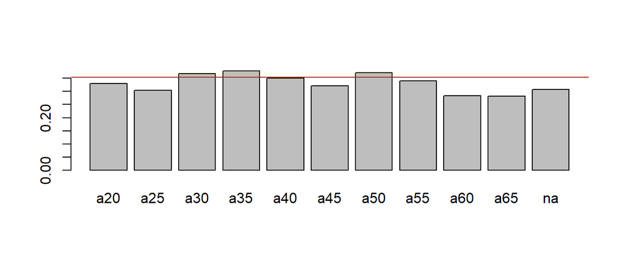

```r
tapply(cat4A$buy, cat4A$age, mean) %>% barplot
abline(h = mean(cat4A$buy), col='red')
```

### 2.2.10 地區與回購率

從地區購買機率來看，106大安區的回購率最高。

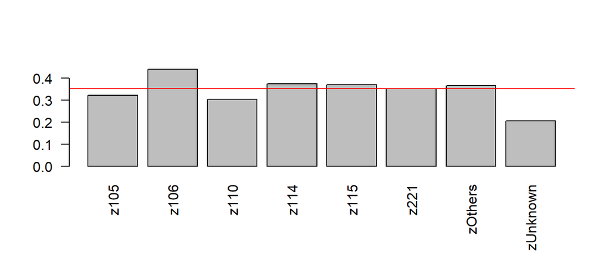

```r
tapply(cat4A$buy, cat4A$area, mean) %>% barplot(las=2)
abline(h = mean(cat4A$buy), col='red')
```

> 統合此類產品特徵：  
> 1. 購買次數大多落在1次，回購率低，銷售目標為吸引新顧客購買為主。  
> 2. 年齡層主要落在30-40歲之間，而11月後半至12月初與1月中的銷售情況較佳。  
> 3. 平均客單價為877元，並沒有很高。  
> 4. 相較於其他產品，信義區客人反而會來買這樣商品，但看回購率的話，大安區的回購機率高。  
> 5. 從毛利趨勢圖來看，一月的毛利較低，但是銷售量卻算高，推估當時可能是因為折價、薄利多銷促進買氣。

> > 此品類商品假設：冬季保暖衣物，在冬季開始前與過年時都有明顯很好的買氣。然而以毛利情況來看，成本高毛利低，應為薄利多銷的冬季衣物產品。

## 2.3 編號530101－衛生紙生活用品類

### 2.3.1 概覽

```r
cat5 = subset(Z, cat=="530101") #篩選出320402品類資料

cat6 = cat5 %>% group_by(tid) %>% summarise(
  date = date[1],             # 交易日期
  cust = cust[1],             # 顧客 ID
  age = age[1],               # 顧客 年齡級別
  area = area[1],             # 顧客 居住區別
  items = n(),                # 交易項目(總)數
  pieces = sum(qty),          # 產品(總)件數
  total = sum(price),         # 交易(總)金額
  gross = sum(price - cost)   # 毛利
  ) %>% data.frame
nrow(cat6) # 6774筆訂單
```

```
## [1] 6774
```

```r
summary(cat6)
```

```
##       tid              date                cust
##  Min.   :    36   Min.   :2000-11-01   Length:6774
##  1st Qu.: 31127   1st Qu.:2000-11-30   Class :character
##  Median : 57773   Median :2000-12-31   Mode  :character
##  Mean   : 59141   Mean   :2000-12-30
##  3rd Qu.: 89401   3rd Qu.:2001-02-02
##  Max.   :119418   Max.   :2001-02-28
##      age                area               items           pieces
##  Length:6774        Length:6774        Min.   :1.000   Min.   : 1.000
##  Class :character   Class :character   1st Qu.:1.000   1st Qu.: 1.000
##  Mode  :character   Mode  :character   Median :1.000   Median : 2.000
##                                        Mean   :1.559   Mean   : 2.116
##                                        3rd Qu.:2.000   3rd Qu.: 3.000
##                                        Max.   :8.000   Max.   :20.000
##      total            gross
##  Min.   :  31.0   Min.   :-80.00
##  1st Qu.:  84.0   1st Qu.: 11.00
##  Median : 138.0   Median : 21.00
##  Mean   : 171.5   Mean   : 27.25
##  3rd Qu.: 219.0   3rd Qu.: 37.00
##  Max.   :1648.0   Max.   :360.00
```

#### 處理離群值

```r
sapply(cat6[,6:9], quantile, prob=c(.999, .9995, .9999))
```

```
##        items  pieces    total    gross
## 99.9%      6 14.0000 1105.013 216.9940
## 99.95%     6 15.6135 1270.724 255.2945
## 99.99%     8 20.0000 1599.234 331.5534
```

```r
cat6 = subset(cat6, items<=62 & pieces<95 & total<16000)
```

### 2.3.2 每周交易次數

在2000年，11月底和12月初的訂單量較高，2001年的二月也有穩定的交易次數。

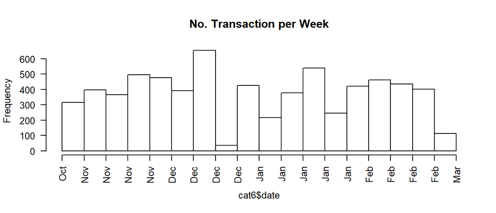

```r
par(cex=0.8)
hist(cat6$date, "weeks", freq=T, las=2, main="No. Transaction per Week")
```

### 2.3.3 偏好購買時間

此品類消費者偏好在假日購物，尤其是禮拜天；30至40歲尤為明顯。

```r
table(cat6$age, format(cat6$date,"%u")) %>%
  {./rowSums(.)}%>%
  as.data.frame.matrix %>%
  d3heatmap(F,F,col=colorRamp(c('seagreen','lightyellow','red')))
```

[interactive chart not shown]

### 2.3.4 各年齡層淨利

從利潤的角度來看，30-50的家庭支柱仍為主要營收貢獻者，其中35-45歲所帶來的利潤最高。

```r
tapply(cat6$gross, cat6$age, sum) %>% sort()
```

```
##   a60   a65   a55    na   a20   a50   a25   a45   a30   a40   a35
##  1969  2075  2496  4223  8923  9688 16646 28190 29998 39274 41139
```

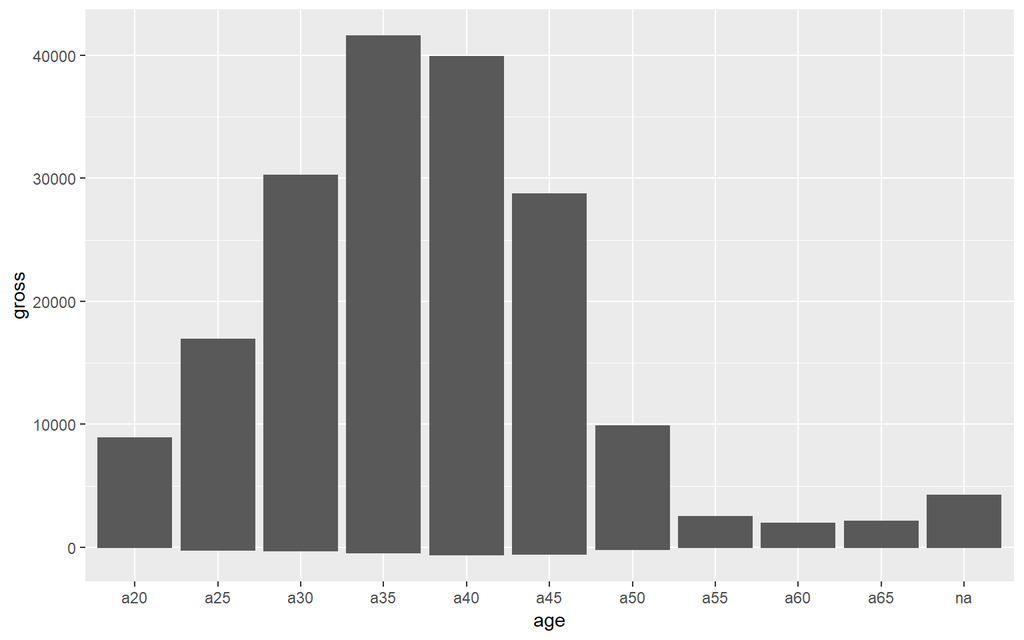

```r
ggplot(cat6, aes(x = age, y = gross) )+
  geom_bar(stat = "identity")
```

### 2.3.5 各區域淨利

根據地區來探索，除了南港與汐止的消費者佔淨利多數，信義區也是貢獻之一。

```r
tapply(cat6$gross,cat6$area, sum) %>% sort()
```

```
##     z105     z106     z114 zUnknown  zOthers     z110     z221     z115
##     4057     4403     8301     8720    15827    19312    50496    73505
```

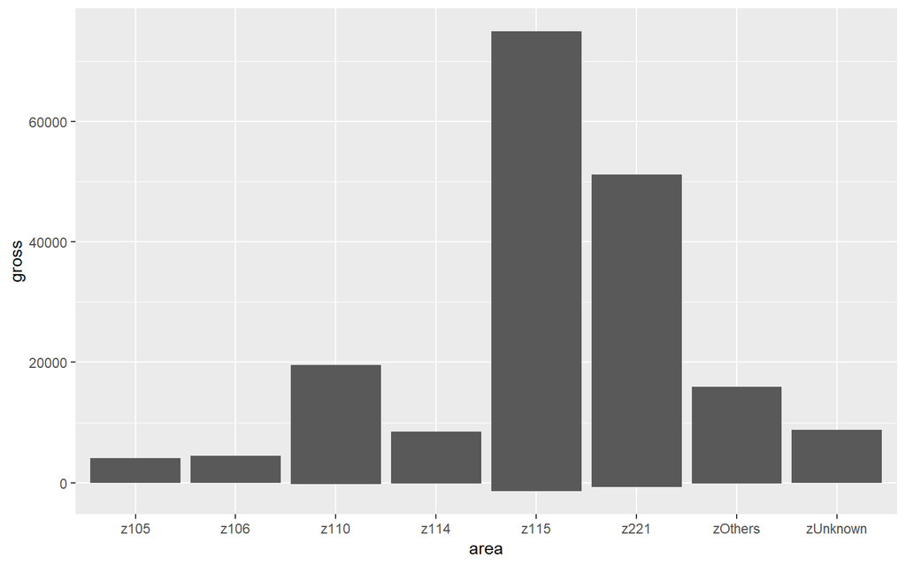

```r
ggplot(cat6, aes(x = area, y = gross) )+
  geom_bar(stat = "identity")
```

### 2.1.6 顧客消費資料變數分布

```r
d1 = max(cat6$date) + 1
cat6A = cat6 %>% mutate(
  days = as.integer(difftime(d1, date, units="days"))
  ) %>%
  group_by(cust) %>% summarise(
    r = min(days),      # recency
    s = max(days),      # seniority
    f = n(),            # frquency
    m = mean(total),    # monetary #平均客單價
    rev = sum(total),   # total revenue contribution
    raw = sum(gross),   # total gross profit contribution
    age = age[1],       # age group
    area = area[1],     # area code
  ) %>% data.frame
nrow(cat6A) # 5148位顧客
```

```
## [1] 5148
```

```r
summary(cat6A)
```

```
##      cust                 r                s                f
##  Length:5148        Min.   :  1.00   Min.   :  1.00   Min.   : 1.000
##  Class :character   1st Qu.: 21.75   1st Qu.: 38.00   1st Qu.: 1.000
##  Mode  :character   Median : 48.00   Median : 75.00   Median : 1.000
##                     Mean   : 54.00   Mean   : 66.67   Mean   : 1.316
##                     3rd Qu.: 84.00   3rd Qu.: 96.00   3rd Qu.: 1.000
##                     Max.   :120.00   Max.   :120.00   Max.   :16.000
##        m               rev              raw             age
##  Min.   :  37.0   Min.   :  37.0   Min.   :-79.00   Length:5148
##  1st Qu.:  89.0   1st Qu.:  98.0   1st Qu.: 12.00   Class :character
##  Median : 141.8   Median : 168.0   Median : 25.00   Mode  :character
##  Mean   : 171.4   Mean   : 225.7   Mean   : 35.86
##  3rd Qu.: 219.0   3rd Qu.: 279.2   3rd Qu.: 47.00
##  Max.   :1576.0   Max.   :3308.0   Max.   :476.00
##      area
##  Length:5148
##  Class :character
##  Mode  :character
##
##
##
```

### 2.3.7 變數分布檢視

- recently：此品類消費顧客平均最近購買在距今54天內，幾乎每一天都有持續的購買量。
- seniority：在距今70天前，是大量新顧客湧入的期間；近期新顧客反而比較少。
- frequency：消費者購買次數多為1至2次。
- money：平均客單價之平均為171元，非常低。

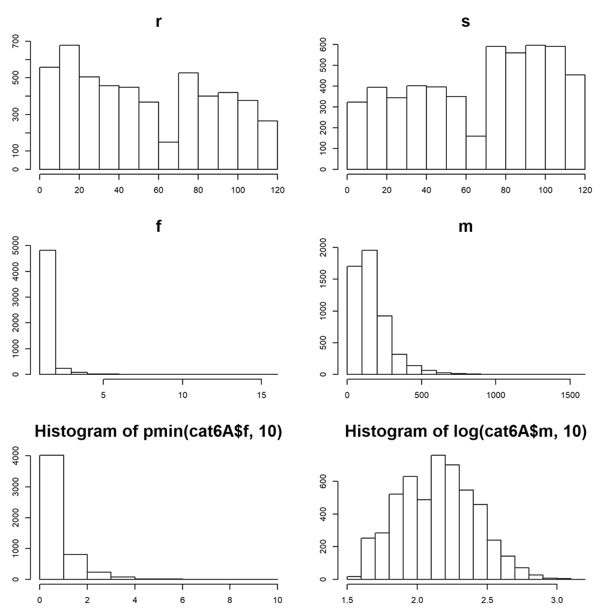

```r
par(mfrow=c(3,2), mar=c(3,3,4,2))
for(x in c('r','s','f','m'))
hist(cat6A[,x],freq=T,main=x,xlab="",ylab="",cex.main=2)
hist(pmin(cat6A$f,10),0:10,freq=T,xlab="",ylab="",cex.main=2)
hist(log(cat6A$m,10),freq=T,xlab="",ylab="",cex.main=2)
```

### 2.3.8 回購機率摘要

```r
feb01 = as.Date("2001-02-01")
cat5 = subset(cat5, date < feb01)
feb = filter(cat6, date>= feb01) %>% group_by(cust) %>%
  summarise(amount = sum(total))


cat6A= merge(cat6A, feb, by="cust", all.x=T)
cat6A$buy = !is.na(cat6A$amount)

summary(cat6A)
```

```
##      cust                 r                s                f
##  Length:5148        Min.   :  1.00   Min.   :  1.00   Min.   : 1.000
##  Class :character   1st Qu.: 21.75   1st Qu.: 38.00   1st Qu.: 1.000
##  Mode  :character   Median : 48.00   Median : 75.00   Median : 1.000
##                     Mean   : 54.00   Mean   : 66.67   Mean   : 1.316
##                     3rd Qu.: 84.00   3rd Qu.: 96.00   3rd Qu.: 1.000
##                     Max.   :120.00   Max.   :120.00   Max.   :16.000
##
##        m               rev              raw             age
##  Min.   :  37.0   Min.   :  37.0   Min.   :-79.00   Length:5148
##  1st Qu.:  89.0   1st Qu.:  98.0   1st Qu.: 12.00   Class :character
##  Median : 141.8   Median : 168.0   Median : 25.00   Mode  :character
##  Mean   : 171.4   Mean   : 225.7   Mean   : 35.86
##  3rd Qu.: 219.0   3rd Qu.: 279.2   3rd Qu.: 47.00
##  Max.   :1576.0   Max.   :3308.0   Max.   :476.00
##
##      area               amount         buy
##  Length:5148        Min.   : 42.0   Mode :logical
##  Class :character   1st Qu.: 87.0   FALSE:3486
##  Mode  :character   Median :138.0   TRUE :1662
##                     Mean   :173.8
##                     3rd Qu.:223.0
##                     Max.   :942.0
##                     NA's   :3486
```

### 2.3.9 年齡與回購率

撇除不曉得年齡者，40歲至50歲的回購率比較高，然而50歲以上的回購率則是非常低，應不是我們的主要客戶。

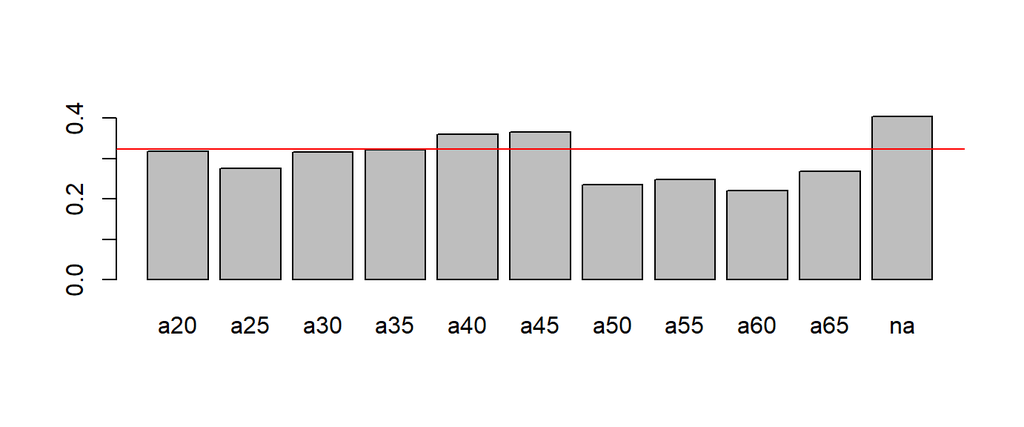

```r
tapply(cat6A$buy, cat6A$age, mean) %>% barplot
abline(h = mean(cat6A$buy), col='red')
```

### 2.3.10 地區與回購率

大部分的地區回購機率都差不多，除了106大安為最低的回購機率。

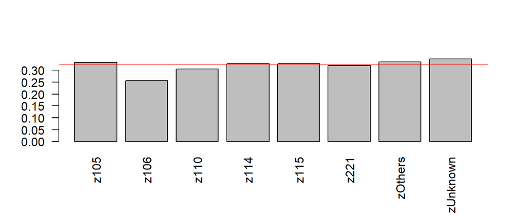

```r
tapply(cat6A$buy, cat6A$area, mean) %>% barplot(las=2)
abline(h = mean(cat6A$buy), col='red')
```

> > 此類商品假設：由於此類商品單價較低，成本也低，而持續有一定購買數量，故假設此類商品為衛生紙生活用品。

# 參、整體與品類分群

```r
load("final.rdata")
```

## 3.1 整體kmeans分群與命名

### 3.1.1 資料前處理

```r
AA = CData
AA[,c(2:7, 10)] = scale(AA[,c(2:7, 10)])

AA$age = factor(AA$age)
AA$area = factor(AA$area)
AA$buy = factor(AA$buy)
DummyTable <- model.matrix( ~ age + area + buy, data = AA)
AA <- cbind(
  AA[, -c(1, 8, 9, 11:15)],
  DummyTable[, -1]
)
AA$amount[is.na(AA$amount)] = 0
```

### 3.1.2 分群：

```r
set.seed(500)
K <- kmeans(AA, 3)
ClusterResult <- cbind(
  AA,
  K$cluster
) %>% as.data.frame()
colnames(ClusterResult)[ncol(ClusterResult)] <- 'Cluster'
table(ClusterResult$Cluster)
```

```
##
##     1     2     3
##  7024 14286  3561
```

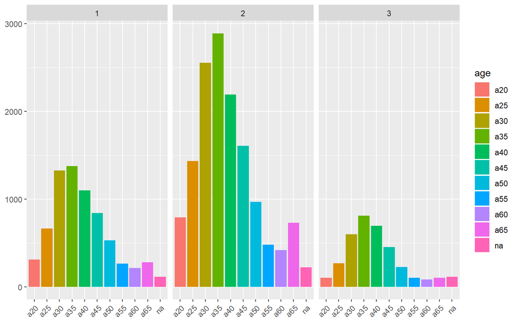

```r
A <- CData[, -c(12:15)] %>%
  cbind(K$cluster) %>%
  as.data.frame()
colnames(A)[ncol(A)] <- 'Cluster'

ggplot(data = A) +
  geom_bar(aes(x = age, fill = age)) +
  facet_wrap( ~ Cluster) +
  theme(axis.text.x = element_text(angle = 45, hjust = 1, vjust = 1),
        axis.title = element_blank())
```

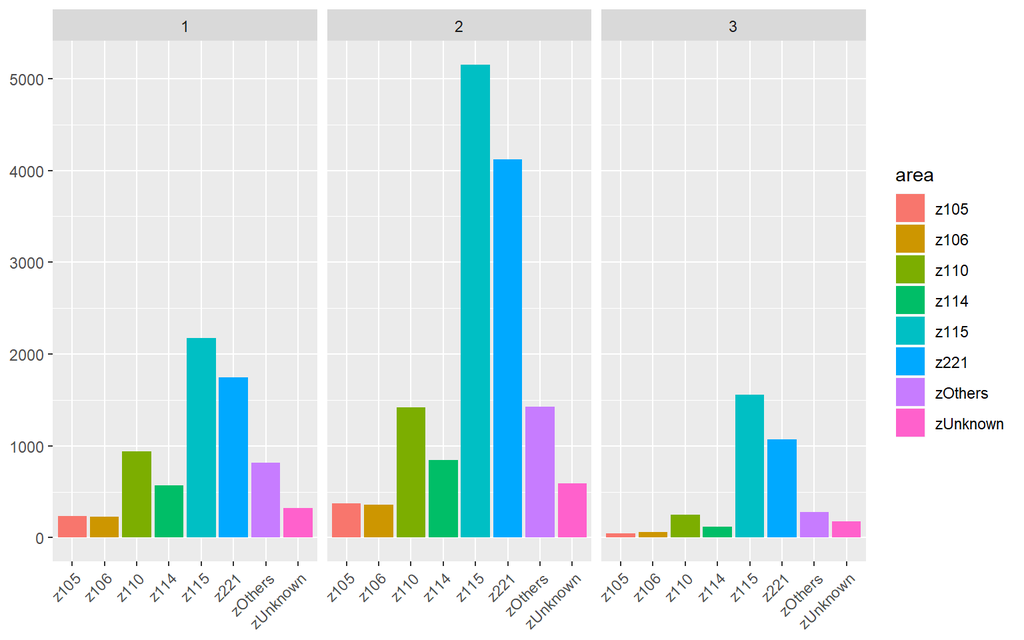

```r
ggplot(data = A) +
  geom_bar( aes( x = area, fill = area)) +
  facet_wrap( ~ Cluster) +
  theme(axis.text.x = element_text(angle = 45, hjust = 1, vjust = 1),
        axis.title = element_blank())
```

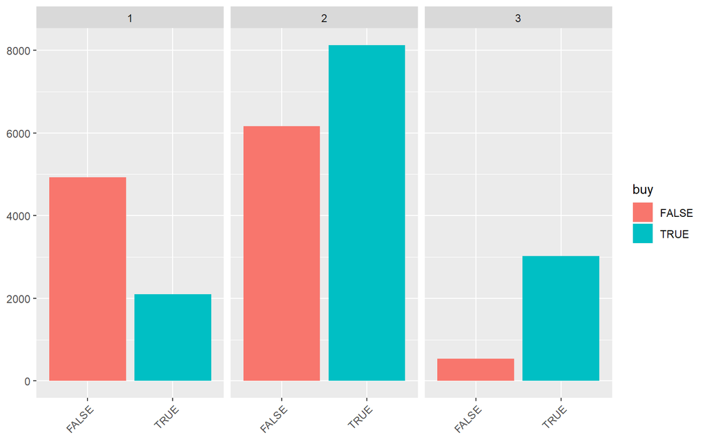

```r
ggplot(data = A) +
  geom_bar(aes(x = buy, fill = buy)) +
  facet_wrap( ~ Cluster) +
  theme(axis.text.x = element_text(angle = 45, hjust = 1, vjust = 1),
        axis.title = element_blank())
```

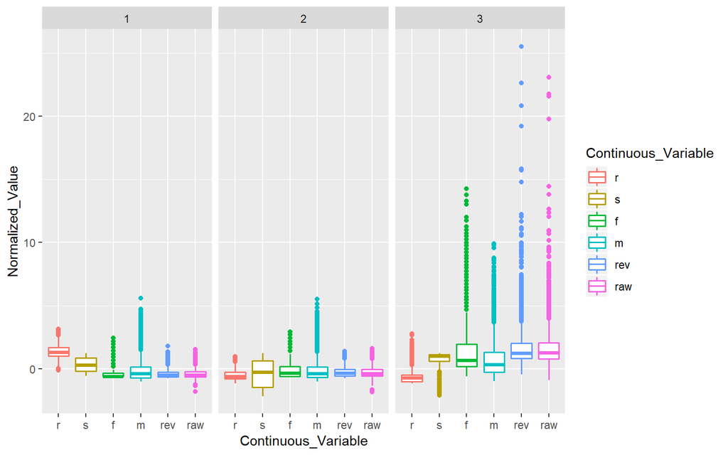

```r
AA1 = CData
AA1[,c(2:7, 10)] = scale(AA1[,c(2:7, 10)])

AA1$age = factor(AA1$age)
AA1$area = factor(AA1$area)
AA1$buy = factor(AA1$buy)
DummyTable <- model.matrix( ~ age + area + buy, data = AA1)
AA1 <- cbind(
  AA1[, -c(1, 8, 9, 11,13:15)],
  DummyTable[, -1]
)
AA1$amount[is.na(AA$amount)] = 0

ClusterResultForPlot <- AA1 %>%
  gather( key = Continuous_Variable,
          value = Normalized_Value,
          - c(amount, agea25, agea30, agea35, agea40, agea45,
              agea50, agea55, agea60, agea65, agena,
              areaz106, areaz110, areaz114, areaz115, areaz221,
              areazOthers, areazUnknown, buyTRUE,Cluster))

ClusterResultForPlot$Continuous_Variable <- ClusterResultForPlot$Continuous_Variable %>% factor( levels = c('r', 's', 'f', 'm', 'rev', 'raw'))

ggplot( data = ClusterResultForPlot) +
  geom_boxplot( aes( x = Continuous_Variable,
                     y = Normalized_Value,
                    color = Continuous_Variable),
                size = 0.7) +
  facet_wrap( ~ Cluster)
```

整體來看：

## 3.2 家電類kmeans分群與命名

### 3.2.2 分群：

```r
set.seed(500)
K <- kmeans(AA, 3)
ClusterResult <- cbind(
  AA,
  K$cluster
) %>% as.data.frame()
colnames(ClusterResult)[ncol(ClusterResult)] <- 'Cluster'
table(ClusterResult$Cluster)
```

[output not shown]

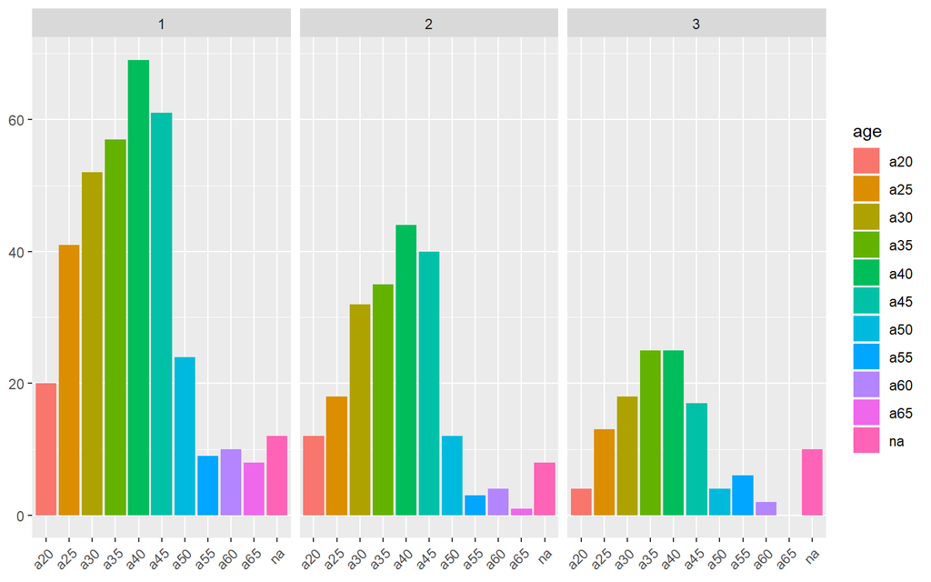

```r
A <- cat2A[, -c(12:15)] %>%
  cbind(K$cluster) %>%
  as.data.frame()
colnames(A)[ncol(A)] <- 'Cluster'

ggplot(data = A) +
  geom_bar(aes(x = age, fill = age)) +
  facet_wrap( ~ Cluster) +
  theme(axis.text.x = element_text(angle = 45, hjust = 1, vjust = 1),
        axis.title = element_blank())
```

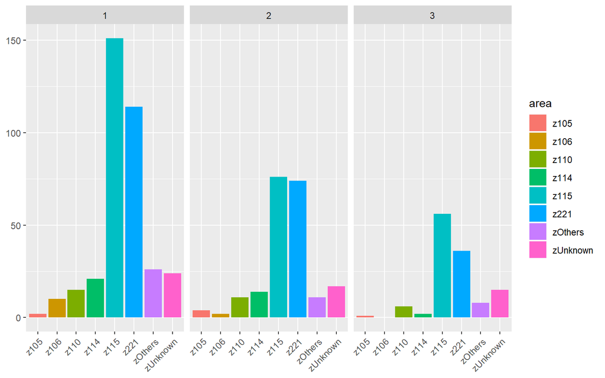

```r
ggplot(data = A) +
  geom_bar( aes( x = area, fill = area)) +
  facet_wrap( ~ Cluster) +
  theme(axis.text.x = element_text(angle = 45, hjust = 1, vjust = 1),
        axis.title = element_blank())
```

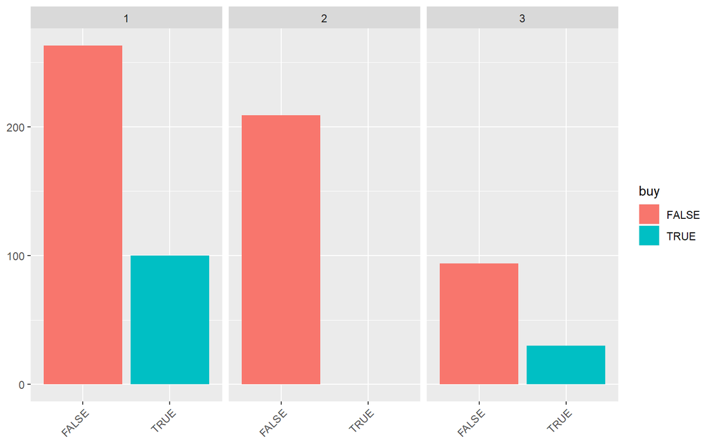

```r
ggplot(data = A) +
  geom_bar(aes(x = buy, fill = buy)) +
  facet_wrap( ~ Cluster) +
  theme(axis.text.x = element_text(angle = 45, hjust = 1, vjust = 1),
        axis.title = element_blank())
```

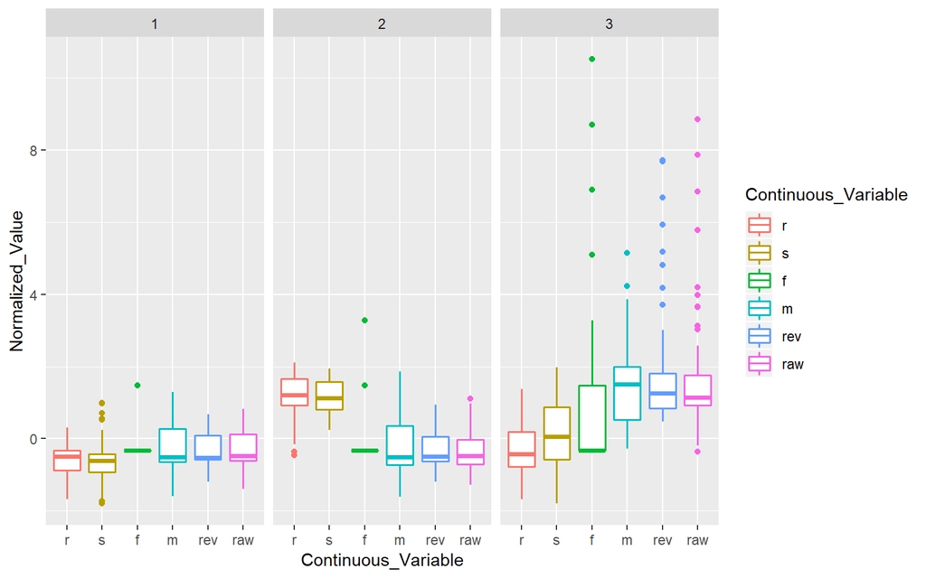

```r
A[,c(2:7, 10)] = scale(A[,c(2:7, 10)])

A$age = factor(A$age)
A$area = factor(A$area)
A$buy = factor(A$buy)
DummyTable <- model.matrix( ~ age + area + buy, data = A)
A <- cbind(
  A[, -c(1, 8, 9, 11,13:15)],
  DummyTable[, -1]
)
A$amount[is.na(A$amount)] = 0

ClusterResultForPlot <- A %>%
  gather( key = Continuous_Variable,
          value = Normalized_Value,
          - c(amount, agea25, agea30, agea35, agea40, agea45,
              agea50, agea55, agea60, agea65, agena,
              areaz106, areaz110, areaz114, areaz115, areaz221,
              areazOthers, areazUnknown, buyTRUE,Cluster))

ClusterResultForPlot$Continuous_Variable <- ClusterResultForPlot$Continuous_Variable %>% factor( levels = c('r', 's', 'f', 'm', 'rev', 'raw'))

ggplot( data = ClusterResultForPlot) +
  geom_boxplot( aes( x = Continuous_Variable,
                     y = Normalized_Value,
                    color = Continuous_Variable),
                size = 0.7) +
  facet_wrap( ~ Cluster)
```